# Exploratory Spatial Data Analysis Airbnb Listing Price By Thuc Dao

### Install libraries

Install geopandas in a new environment.

Run the following codes in the **Anaconda command prompt**.

```python
conda create -n geo_env
conda activate geo_env
conda config  --env --add channels conda-forge
conda config --env --set channel_priority strict
conda install geopandas
conda install jupyter notebook
python -m ipykernel install --name geo_env
conda activate geo_env
jupyter notebook
```

Remember to choose the geo_env environment in order to use the geopandas library.

If you forget it, you can also change the environment inside the Jupyter notebook, by selecting in the menu: Kernel >>> Change Kernel >>> geo_env

```python
pip install folium
```

```python
pip install libpysal
```

```python
pip install esda
```

```python
pip install splot
```

### Import libraries

```python
import pandas as pd
import matplotlib.pyplot as plt
import folium
import geopandas as gpd
import libpysal as lps
import esda
from esda.moran import Moran, Moran_Local
from splot.esda import lisa_cluster
```

### Choose a city

```python
city = 'Toronto'
```

```python
if city == 'Montreal':
    city_coordinate = [45.50888, -73.56166]
    zoom_level = 10
    listings_file = r'https://github.com/ThucDao/ExploratorySpatialDataAnalysis/blob/main/input/listings_Montreal_QC_Canada_2022_03_12.csv?raw=true'
    neighbourhoods_file = r'https://github.com/ThucDao/ExploratorySpatialDataAnalysis/blob/main/input/neighbourhoods_Montreal_QC_Canada.geojson?raw=true'
elif city == 'Quebec City':
    city_coordinate = [46.84885, -71.33402]
    zoom_level = 11
    listings_file = r'https://github.com/ThucDao/ExploratorySpatialDataAnalysis/blob/main/input/listings_Quebec%20City_QC_Canada_2022_03_09.csv?raw=true'
    neighbourhoods_file = r'https://github.com/ThucDao/ExploratorySpatialDataAnalysis/blob/main/input/neighbourhoods_Quebec%20City_QC_Canada.geojson?raw=true'
elif city == 'Toronto':
    city_coordinate = [43.69511, -79.31482]
    zoom_level = 11
    listings_file = r'https://github.com/ThucDao/ExploratorySpatialDataAnalysis/blob/main/input/listings_Toronto_ON_Canada_2022_03_08.csv?raw=true'
    neighbourhoods_file = r'https://github.com/ThucDao/ExploratorySpatialDataAnalysis/blob/main/input/neighbourhoods_Toronto_ON_Canada.geojson?raw=true'
elif city == 'Vancouver':
    city_coordinate = [49.24966, -123.11934]
    zoom_level = 12
    listings_file = r'https://github.com/ThucDao/ExploratorySpatialDataAnalysis/blob/main/input/listings_Vancouver_BC_Canada_2022_03_10.csv?raw=true'
    neighbourhoods_file = r'https://github.com/ThucDao/ExploratorySpatialDataAnalysis/blob/main/input/neighbourhoods_Vancouver_BC_Canada.geojson?raw=true'
elif city == 'Victoria':
    city_coordinate = [48.60732, -123.72977]
    zoom_level = 9
    listings_file = r'https://github.com/ThucDao/ExploratorySpatialDataAnalysis/blob/main/input/listings_Victoria_BC_Canada_2022_03_29.csv?raw=true'
    neighbourhoods_file = r'https://github.com/ThucDao/ExploratorySpatialDataAnalysis/blob/main/input/neighbourhoods_Victoria_BC_Canada.geojson?raw=true'
elif city == 'Winnipeg':
    city_coordinate = [49.79507, -97.13845]
    zoom_level = 10
    listings_file = r'https://github.com/ThucDao/ExploratorySpatialDataAnalysis/blob/main/input/listings_Winnipeg_MB_Canada_2022_06_08.csv?raw=true'
    neighbourhoods_file = r'https://github.com/ThucDao/ExploratorySpatialDataAnalysis/blob/main/input/neighbourhoods_Winnipeg_MB_Canada.geojson?raw=true'
```

### Load listings data of the chosen city

```python
df = pd.read_csv(listings_file)
```

```python
print(f'{df.shape[0]} rows, {df.shape[1]} columns')
```

```
15418 rows, 18 columns
```

```python
df.head(5)
```

|  | id | name | host_id | host_name | neighbourhood_group | neighbourhood | latitude | longitude | room_type | price | minimum_nights | number_of_reviews | last_review | reviews_per_month | calculated_host_listings_count | availability_365 | number_of_reviews_ltm | license |
| --- | --- | --- | --- | --- | --- | --- | --- | --- | --- | --- | --- | --- | --- | --- | --- | --- | --- | --- |
| 0 | 44419781 | Studio Suite \| Business Travel | 348430184 | Avalon | NaN | Annex | 43.67127 | -79.39461 | Entire home/apt | 155 | 2 | 34 | 2022-01-30 | 1.86 | 33 | 308 | 21 | STR-2011-HPXRVK |
| 1 | 44429201 | Beautiful & Cozy One Bedroom Condo In Yorkville! | 354808129 | Erin | NaN | Annex | 43.67142 | -79.39487 | Entire home/apt | 120 | 30 | 3 | 2021-10-31 | 0.17 | 7 | 35 | 2 | NaN |
| 2 | 44429908 | Stylish Roncesvalles Private Suite w/ Tech Extras | 37415518 | Anthony | NaN | Roncesvalles | 43.64055 | -79.43939 | Entire home/apt | 95 | 3 | 37 | 2022-02-04 | 2.78 | 1 | 117 | 35 | STR-2012-FVZBHD |
| 3 | 44430872 | Newly Renovated 2nd floor Suite | 358865808 | Joe | NaN | Weston-Pellam Park | 43.66801 | -79.45752 | Entire home/apt | 115 | 3 | 4 | 2022-01-02 | 1.08 | 1 | 79 | 4 | STR-2110-FXJVHD |
| 4 | 44433011 | Spacious, Cozy 1 Bedroom Loft in downtown Toronto | 20355052 | Turgut | NaN | Regent Park | 43.65806 | -79.35499 | Entire home/apt | 160 | 28 | 0 | NaN | NaN | 1 | 29 | 0 | NaN |

### Load neighbourhoods geodata of the chosen city

```python
gdf = gpd.read_file(neighbourhoods_file)
```

```python
print(f'{gdf.shape[0]} rows, {gdf.shape[1]} columns')
```

```
140 rows, 3 columns
```

```python
gdf.head(5)
```

|  | neighbourhood | neighbourhood_group | geometry |
| --- | --- | --- | --- |
| 0 | York University Heights | None | MULTIPOLYGON (((-79.50529 43.75987, -79.50488 ... |
| 1 | The Beaches | None | MULTIPOLYGON (((-79.31485 43.66674, -79.31356 ... |
| 2 | Scarborough Village | None | MULTIPOLYGON (((-79.21397 43.72676, -79.21400 ... |
| 3 | South Parkdale | None | MULTIPOLYGON (((-79.42777 43.62979, -79.42948 ... |
| 4 | South Riverdale | None | MULTIPOLYGON (((-79.32868 43.64745, -79.32867 ... |

### Join two datasets and calculate the average price

Convert a dataframe to a geodataframe using Coordinate Reference Systems (CRS) EPSG:4326 (World Geodetic System WGS84).

```python
gdf_listings = gpd.GeoDataFrame(df, geometry=gpd.points_from_xy(df['longitude'], df['latitude']), crs='EPSG:4326')
```

Join spatially two datasets

```python
gdf_price = gpd.sjoin(gdf, gdf_listings[['price','geometry']], predicate='contains')
```

```python
print(f'{gdf_price.shape[0]} rows, {gdf_price.shape[1]} columns')
```

```
15342 rows, 5 columns
```

```python
gdf_price.head(5)
```

|  | neighbourhood | neighbourhood_group | geometry | index_right | price |
| --- | --- | --- | --- | --- | --- |
| 0 | York University Heights | None | MULTIPOLYGON (((-79.50529 43.75987, -79.50488 ... | 14129 | 39 |
| 0 | York University Heights | None | MULTIPOLYGON (((-79.50529 43.75987, -79.50488 ... | 5681 | 59 |
| 0 | York University Heights | None | MULTIPOLYGON (((-79.50529 43.75987, -79.50488 ... | 13693 | 99 |
| 0 | York University Heights | None | MULTIPOLYGON (((-79.50529 43.75987, -79.50488 ... | 8438 | 50 |
| 0 | York University Heights | None | MULTIPOLYGON (((-79.50529 43.75987, -79.50488 ... | 9030 | 45 |

Calculate the average price for each neighbourhood

```python
gdf_temp = gdf_price['price'].groupby([gdf['neighbourhood']]).mean()
gdf_avg_price = gdf.merge(gdf_temp, on='neighbourhood')
gdf_avg_price.rename(columns={'price':'avg_price'}, inplace=True)
```

```python
print(f'{gdf_avg_price.shape[0]} rows, {gdf_avg_price.shape[1]} columns')
```

```
140 rows, 4 columns
```

```python
gdf_avg_price.head(5)
```

|  | neighbourhood | neighbourhood_group | geometry | avg_price |
| --- | --- | --- | --- | --- |
| 0 | York University Heights | None | MULTIPOLYGON (((-79.50529 43.75987, -79.50488 ... | 62.588608 |
| 1 | The Beaches | None | MULTIPOLYGON (((-79.31485 43.66674, -79.31356 ... | 174.951049 |
| 2 | Scarborough Village | None | MULTIPOLYGON (((-79.21397 43.72676, -79.21400 ... | 113.200000 |
| 3 | South Parkdale | None | MULTIPOLYGON (((-79.42777 43.62979, -79.42948 ... | 116.841410 |
| 4 | South Riverdale | None | MULTIPOLYGON (((-79.32868 43.64745, -79.32867 ... | 169.979094 |

### Create an interactive choropleth map of the average listing price

```python
map_avg_price = folium.Map(location=city_coordinate, zoom_start=zoom_level)
folium.TileLayer('CartoDB positron').add_to(map_avg_price)
title = f'''<h3 align="center"><b>Airbnb Average Listing Price in {city}, March 2022</b></h3>'''
map_avg_price.get_root().html.add_child(folium.Element(title))

choropleth = folium.Choropleth(
                                geo_data=gdf_avg_price,
                                data=gdf_avg_price,
                                bins=10,
                                columns=['neighbourhood', 'avg_price'],
                                key_on='feature.properties.neighbourhood',
                                line_color='black',
                                line_width=1,
                                fill_color='RdYlGn_r',
                                fill_opacity=0.5,
                                line_opacity=0.5,
                                legend_name='CAD'
            ).add_to(map_avg_price)

choropleth.geojson.add_child(folium.features.GeoJsonTooltip(
                                                            fields=['neighbourhood','avg_price'],
                                                            aliases=['Neighbourhood','Average price'],
                                                            labels=True,
                                                            localize=True))
map_avg_price
```

Make this Notebook Trusted to load map: File -> Trust Notebook

[interactive chart not shown]

```python
map_avg_price.save(f'Airbnb_price_{city}.html')
```

### Create 3 static choropleth maps of the average listing price

[1] A choropleth map with classification by equal intervals (classification that divides the data into equal size classes)

[figure not shown]

```python
fig, ax = plt.subplots(figsize=(12, 10))
gdf_avg_price.plot(column='avg_price', scheme='equal_interval', k=10, cmap='RdYlGn_r', legend=True, ax=ax,
                  legend_kwds={'loc':'center left', 'bbox_to_anchor':(1,0.5), 'fmt':"{:.0f}", 'interval':True})
gdf_avg_price.boundary.plot(ax=ax)
plt.title(f'Airbnb Average Listing Price by Equal Intervals in {city}, March 2022', fontsize = 18)
plt.axis('off')
plt.tight_layout()
plt.savefig(f'Airbnb_price_{city}_equal_intervals.png')
plt.show()
```

[2] A choropleth map with classification by quantiles (classification that places an equal number of observations in each class)

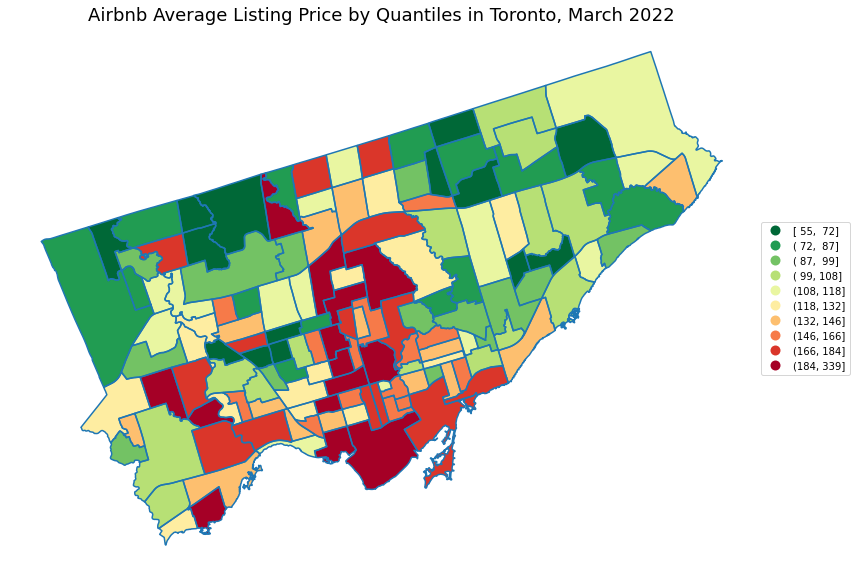

```python
fig, ax = plt.subplots(figsize=(12, 10))
gdf_avg_price.plot(column='avg_price', scheme='quantiles', k=10, cmap='RdYlGn_r', legend=True, ax=ax,
                  legend_kwds={'loc':'center left', 'bbox_to_anchor':(1,0.5), 'fmt':"{:.0f}", 'interval':True})
gdf_avg_price.boundary.plot(ax=ax)
plt.title(f'Airbnb Average Listing Price by Quantiles in {city}, March 2022', fontsize = 18)
plt.axis('off')
plt.tight_layout()
plt.savefig(f'Airbnb_price_{city}_quantiles.png')
plt.show()
```

[3] A choropleth map with classification by natural breaks (classification that minimizes within-class variance and maximizes between-class differences)

[figure not shown]

```python
fig, ax = plt.subplots(figsize=(12, 10))
gdf_avg_price.plot(column='avg_price', scheme='natural_breaks', k=10, cmap='RdYlGn_r', legend=True, ax=ax,
                  legend_kwds={'loc':'center left', 'bbox_to_anchor':(1,0.5), 'fmt':"{:.0f}", 'interval':True})
gdf_avg_price.boundary.plot(ax=ax)
plt.title(f'Airbnb Average Listing Price by Natural Breaks in {city}, March 2022', fontsize = 18)
plt.axis('off')
plt.tight_layout()
plt.savefig(f'Airbnb_price_{city}_natural_breaks.png')
plt.show()
```

### Measures of spatial autocorrelation: spatial similarity and attribute similarity

**Spatial similarity**, measured by spatial weights, shows the relative strength of a relationship between pairs of locations.

Here we compute spatial weights using the Queen contiguity (8 directions).

```python
w = lps.weights.Queen.from_dataframe(gdf_avg_price)
w.transform = 'r'
```

**Attribute similarity**, measured by spatial lags, is a summary of the similarity (or dissimilarity) of observations for a variable at different locations.

The spatial lag takes the average value in each weighted neighborhood.

```python
gdf_avg_price['weighted_price'] = lps.weights.lag_spatial(w, gdf_avg_price['avg_price'])
```

### Global spatial autocorrelation with Moran’s I statistics

Moran’s I is a way to measure spatial autocorrelation. In simple terms, it’s a way to quantify how closely values are clustered together in a 2-D space.

Moran’s I Test uses the following null and alternative hypotheses:

- Null Hypothesis: The data is randomly dispersed.
- Alternative Hypothesis: The data is not randomly dispersed, i.e., it is either clustered or dispersed in noticeable patterns.

```python
y = gdf_avg_price['avg_price']
moran = Moran(y, w)
print(f"Moran's I value: {moran.I}\np-value: {moran.p_sim}")
```

```
Moran's I value: 0.37939917945817603
p-value: 0.001
```

The value of Moran’s I can range from -1 to 1 where:

- -1: The variable of interest is perfectly dispersed
- 0: The variable of interest is randomly dispersed
- 1: The variable of interest is perfectly clustered together

The corresponding p-value can be used to determine whether the data is randomly dispersed or not.

If the p-value is less than a certain significance level (i.e., α = 0.05), then we can reject the null hypothesis and conclude that the data is spatially clustered together in such a way that it is unlikely to have occurred by chance alone.

### Local spatial autocorrelation with Local Indicators of Spatial Association (LISA) statistics

While the global spatial autocorrelation can prove the existence of clusters, or a positive spatial autocorrelation between the listing price and their neighborhoods, it does not show where the clusters are. That is when the local spatial autocorrelation resulted from Local Indicators of Spatial Association (LISA) statistics comes into play.

In general, local Moran’s I values are interpreted as follows:

- Negative: nearby cases are dissimilar or dispersed e.g. High-Low or Low-High
- Neutral: nearby cases have no particular relationship or random, absence of pattern
- Positive: nearby cases are similar or clustered e.g. High-High or Low-Low

The LISA uses local Moran's I values to identify the clusters in localized map regions and categorize the clusters into five types:

- High-High (HH): the area having high values of the variable is surrounded by neighbors that also have high values
- Low-Low (LL): the area having low values of the variable is surrounded by neighbors that also have low values
- Low-High (LH): the area having low values of the variable is surrounded by neighbors that have high values
- High-Low (HL): the area having high values of the variable is surrounded by neighbors that have low values
- Not Significant (NS)

High-High and Low-Low represent positive spatial autocorrelation, while High-Low and Low-High represent negative spatial correlation.

```python
moran_local = Moran_Local(y, w)
```

Create a LISA cluster map at a significance level of 0.05

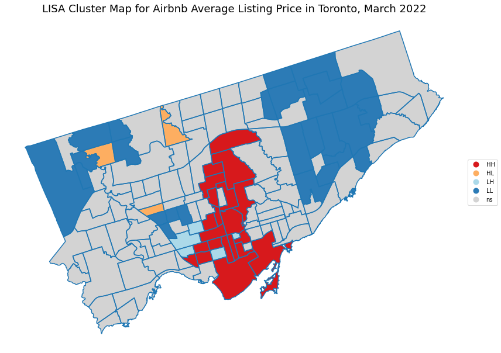

```python
P_VALUE = 0.05

fig, ax = plt.subplots(figsize=(12,10))
lisa_cluster(moran_local, gdf_avg_price, p=P_VALUE, ax=ax, legend=True,
             legend_kwds={'loc':'center left', 'bbox_to_anchor':(1,0.5), 'fmt':"{:.0f}"})
gdf_avg_price.boundary.plot(ax=ax)
plt.title(f'LISA Cluster Map for Airbnb Average Listing Price in {city}, March 2022', fontsize = 18)
plt.tight_layout()
plt.savefig(f'Airbnb_price_{city}_LISA_cluster_map.png')
plt.show()
```